# Final Project

2023-12-06

RESEARCH QUESTION: How is drug use related to crime rate in the United States, and which age group uses the most drugs? Difficulty encountered: I encountered difficulty finding relevant data and cleaning the data so that the two sets could be properly joined. I overcame this error by using statista and kaggle, along with packages existing in R.

```r
# installing crime data package
# install.packages("crimedata")
```

```r
# getting crime data for the years 2010-2015 which are the years i am going to analyze
library(crimedata)
options(repos = c(CRAN = "https://cloud.r-project.org"))
crime_data <- get_crime_data(years = 2010:2015)
# View(crime_data)
```

```r
library(dplyr)
# created a user defined function called extract_year to extract the year from the date_single column using regex
extract_year <- function(date_column) {
  # Apply the regex pattern to the entire column
  year_only <- sub("^([0-9]{4}).*", "\\1", date_column)

  return(year_only)
}
# using my function on the crime_data
crime_data$date_single <- extract_year(crime_data$date_single)
# grouping this data by offense_group and date_single
crime_data_grouped <- crime_data %>%
  group_by(offense_group, date_single) %>%
  summarize(count = n())
# removing NA values
crime_data_grouped<- crime_data_grouped %>%
  filter(!is.na(offense_group) & !is.na(date_single) & !is.na(count))
```

```r
library(readxl)
# importing drug use data
DrugUse <- readr::read_csv("~/Downloads/prevalence-of-drug-use-disorders-by-age.csv")
DrugUse <- DrugUse %>% rename(Country = Entity, Current_Use_AgeStandard =`Current number of cases of drug use disorders per 100 people, in both sexes aged age-standardized`, Current_Use_AllAge = `Current number of cases of drug use disorders per 100 people, in both sexes aged all ages`, Use_Over_70 = `Current number of cases of drug use disorders per 100 people, in both sexes aged 70+ years`, Use_15_to_49 = `Current number of cases of drug use disorders per 100 people, in both sexes aged 15-49 years`, Use_30_to_34 = `Current number of cases of drug use disorders per 100 people, in both sexes aged 30 to 34`, Use_25_to_29 = `Current number of cases of drug use disorders per 100 people, in both sexes aged 25 to 29`, Use_20_to_24 = `Current number of cases of drug use disorders per 100 people, in both sexes aged 20 to 24`, Use_15_to_19 = `Current number of cases of drug use disorders per 100 people, in both sexes aged 15 to 19`, Use_10_to_14 = `Current number of cases of drug use disorders per 100 people, in both sexes aged 10 to 14`, Use_5_to_14 = `Current number of cases of drug use disorders per 100 people, in both sexes aged 5-14 years`)
# View(DrugUse)
# filter so I just see US drug use stats
USdrugs <- DrugUse %>%
  filter(Country == "United States" & Year >= 2010 & Year <= 2015)
# rename date_single to Year
crime_data_grouped <- crime_data_grouped %>% rename(Year = date_single)
# make the column Year into numeric
crime_data_grouped <- crime_data_grouped %>%
  mutate(Year = as.numeric(Year))
# joining data by shared column "Year"
joined_data <- left_join(crime_data_grouped, USdrugs, by = "Year")
# View(joined_data)
```

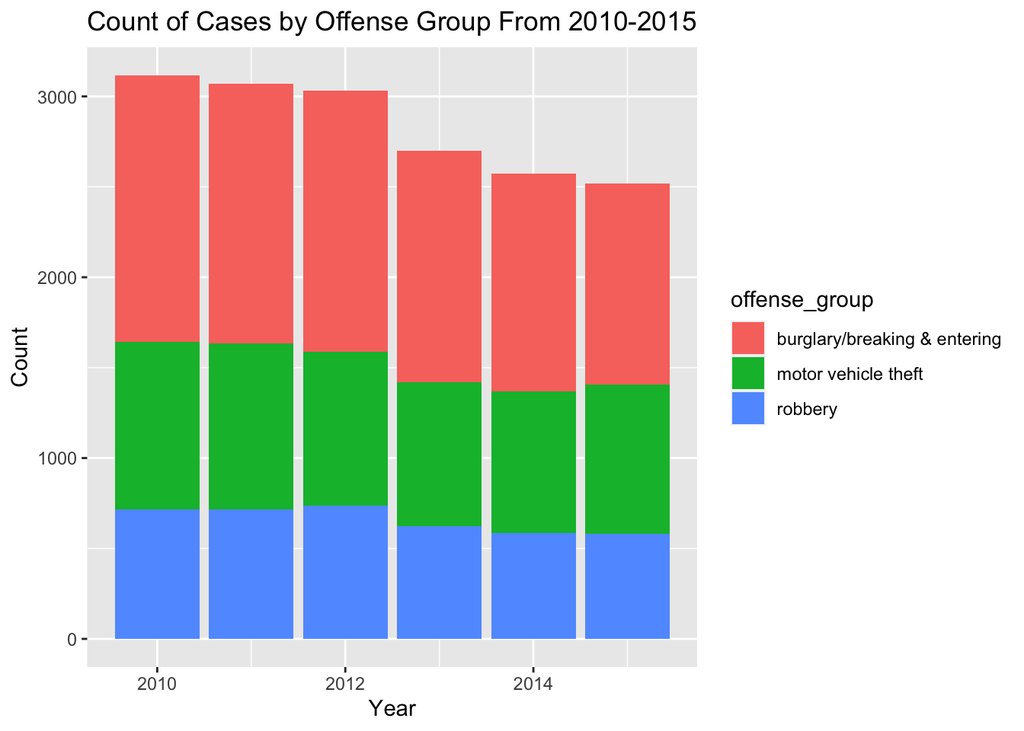

```r
# trying to see the count of each crime per category
library(ggplot2)
crime_data_count <- crime_data %>%
  group_by(offense_group)%>%
  # transformation function
  summarize(count = n())
# selecting different types of crime I want to analyze
selected_offense_groups <- c("burglary/breaking & entering", "motor vehicle theft", "robbery")

selected_crime <- joined_data %>%
  filter(offense_group %in% selected_offense_groups)
ggplot(selected_crime, aes(x = Year, y = count, fill = offense_group)) +
  geom_bar(stat = "identity", position = "stack") +
  labs(title = "Count of Cases by Offense Group From 2010-2015",
       x = "Year",
       y = "Count")
```

As you can tell by this graph, burglary and robbery have notably decreased since 2012, while motor vehicle theft has mostly remained stagnant.

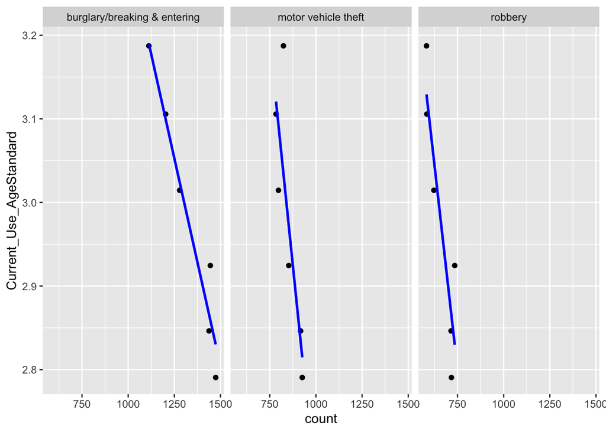

```r
ggplot(selected_crime, aes(x = count, y = Current_Use_AgeStandard)) +
  geom_point()  + geom_smooth(method = "lm", se = FALSE, color = "blue") +
  facet_wrap(~ offense_group)
```

```r
# Now I want to see how drug use fluctuates by age
crime_data_yearly <- crime_data %>%
  group_by(date_single) %>%
  summarize(count = n()) %>%
  filter(date_single > 2009)
```

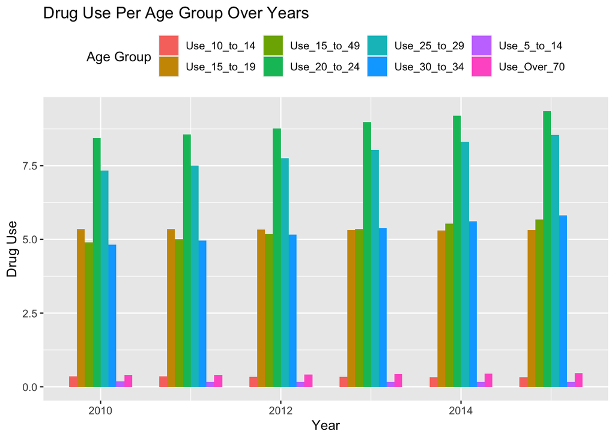

```r
library(tidyr)
crime_data_grouped_yearly <- crime_data_yearly %>% rename(Year = date_single)
# make the column Year into numeric
crime_data_grouped_yearly <- crime_data_grouped_yearly %>%
  mutate(Year = as.numeric(Year))
# joining data by shared column "Year"
joined_data_yearly <- left_join(crime_data_grouped_yearly, USdrugs, by = "Year")
drug_plot <- joined_data_yearly %>%
  select(Year, Use_Over_70, Use_15_to_49, Use_30_to_34, Use_25_to_29, Use_20_to_24, Use_15_to_19, Use_10_to_14, Use_5_to_14) %>%
  gather(key = "AgeGroup", value = "DrugUse", -Year) %>%
  ggplot(aes(x = Year, y = DrugUse, fill = AgeGroup)) +
  geom_bar(stat = "identity", position = "dodge", width = 0.7) +
  labs(title = "Drug Use Per Age Group Over Years", x = "Year", y = "Drug Use", fill = "Age Group") +
  theme(legend.position = "top")
drug_plot
```

As you can see, age group 25 to 29 and age group 20 to 24 use drugs at the highest rate. In a separate project, it could be interesting to analyze which age groups commit crimes at the highest rates.